# ロジスティック回帰モデル

Pythonの機械学習用ライブラリ`scikit-learn`を使って，ロジスティック回帰モデルを使って簡単な分類問題にチャレンジしてみましょう.

### 0.ライブラリのインポート

```python
import numpy as np
import pandas as pd

import sklearn

import seaborn as sns
import matplotlib
import matplotlib.pyplot as plt
%matplotlib inline

np.set_printoptions(precision=4)
```

```python
print("numpy :", np.__version__)
print("pandas :", pd.__version__)
print("sklearn :", sklearn.__version__)
print("seaborn :", sns.__version__)
print("matplotlib :", matplotlib.__version__)
```

```
numpy : 1.16.1
pandas : 0.24.2
sklearn : 0.20.2
seaborn : 0.9.0
matplotlib : 3.0.2
```

### 1. データの読込・整形

`sklearn.datasets`からBreastCancerデータセットを読み込みましょう．

```python
# make data samples
from sklearn.datasets import load_breast_cancer
bc = load_breast_cancer()
```

参考: [pandas.DataFrame — pandas 1.0.1 documentation](https://pandas.pydata.org/pandas-docs/stable/reference/api/pandas.DataFrame.html)

```python
df_data = pd.DataFrame(bc.data, columns=bc.feature_names)
df_data = df_data.loc[:, ['mean concave points', 'symmetry error', 'texture error', 'worst radius']]
df_target = pd.DataFrame(bc.target, columns=['class'])
df = pd.concat([df_data, df_target], axis=1)
df.head()
```

|  | mean concave points | symmetry error | texture error | worst radius | class |
| --- | --- | --- | --- | --- | --- |
| 0 | 0.14710 | 0.03003 | 0.9053 | 25.38 | 0 |
| 1 | 0.07017 | 0.01389 | 0.7339 | 24.99 | 0 |
| 2 | 0.12790 | 0.02250 | 0.7869 | 23.57 | 0 |
| 3 | 0.10520 | 0.05963 | 1.1560 | 14.91 | 0 |
| 4 | 0.10430 | 0.01756 | 0.7813 | 22.54 | 0 |

データの要約統計量(サンプル数, 平均, 標準偏差, 四分位数, 中央値, 最小値, 最大値など)をみましょう．

```python
df.describe().T
```

|  | count | mean | std | min | 25% | 50% | 75% | max |
| --- | --- | --- | --- | --- | --- | --- | --- | --- |
| mean concave points | 569.0 | 0.048919 | 0.038803 | 0.000000 | 0.02031 | 0.03350 | 0.07400 | 0.20120 |
| symmetry error | 569.0 | 0.020542 | 0.008266 | 0.007882 | 0.01516 | 0.01873 | 0.02348 | 0.07895 |
| texture error | 569.0 | 1.216853 | 0.551648 | 0.360200 | 0.83390 | 1.10800 | 1.47400 | 4.88500 |
| worst radius | 569.0 | 16.269190 | 4.833242 | 7.930000 | 13.01000 | 14.97000 | 18.79000 | 36.04000 |
| class | 569.0 | 0.627417 | 0.483918 | 0.000000 | 0.00000 | 1.00000 | 1.00000 | 1.00000 |

```python
df.corr()
```

|  | mean concave points | symmetry error | texture error | worst radius | class |
| --- | --- | --- | --- | --- | --- |
| mean concave points | 1.000000 | 0.095351 | 0.021480 | 0.830318 | -0.776614 |
| symmetry error | 0.095351 | 1.000000 | 0.411621 | -0.128121 | 0.006522 |
| texture error | 0.021480 | 0.411621 | 1.000000 | -0.111690 | 0.008303 |
| worst radius | 0.830318 | -0.128121 | -0.111690 | 1.000000 | -0.776454 |
| class | -0.776614 | 0.006522 | 0.008303 | -0.776454 | 1.000000 |

データの散布図行列を描画します．  
相関が大きい説明変数のペアについては, 多重共線性を考えるべきです.

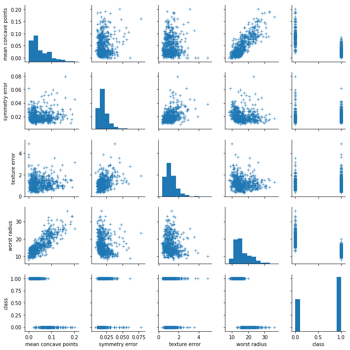

```python
sns.pairplot(df, height=2.0, diag_kind='hist', markers='+')
plt.show()
```

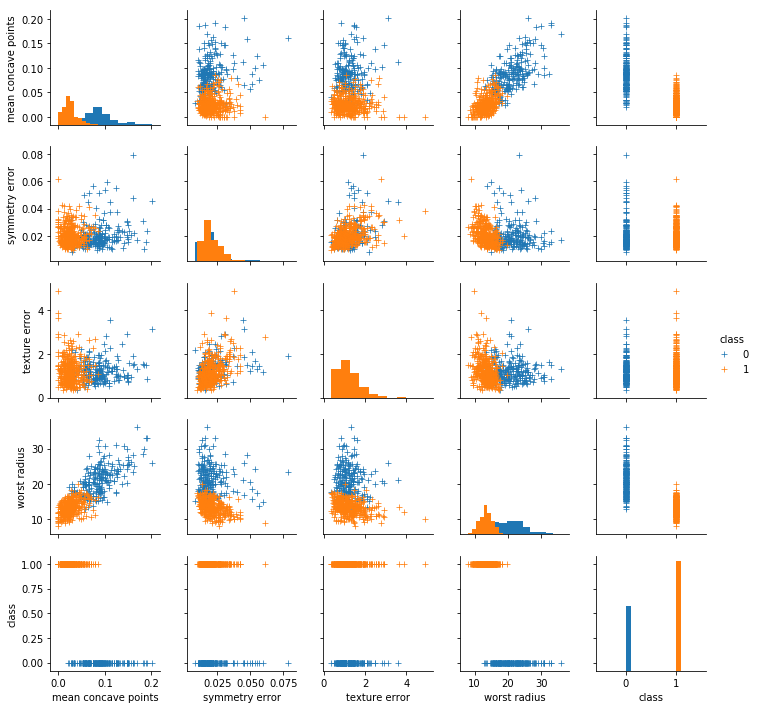

```python
sns.pairplot(df, height=2.0, diag_kind='hist', markers='+', hue='class')
plt.show()
```

### 2. データの分割

pandas DataFrame()クラスの変数`df`から，説明変数と目的変数に相当するデータをそれぞれ取り出し，numpy.ndarray()クラスの変数`X`, `y`へ格納します．

```python
X = df_data.values
y = df_target.values
y = y.reshape(-1)
```

全データをtrainデータとtestデータに分割します． すなわち，変数`X`を`X_train`と`X_test`に， 変数`y`を`y_train`と`y_test`に分けます．

```python
# split data by Hold-out-method
from sklearn.model_selection import train_test_split
X_train, X_test, y_train, y_test = train_test_split(X, y, test_size=0.2, random_state=0)
```

`print()`で配列の形状を確認してみましょう．

```python
print("X_train: ", X_train.shape)
print("y_train: ", y_train.shape)
print("X_test: ", X_test.shape)
print("y_test: ", y_test.shape)
```

```
X_train:  (455, 4)
y_train:  (455,)
X_test:  (114, 4)
y_test:  (114,)
```

- X_train: 4次元データが455コ格納されている．
- y_train: 1次元データが455コ格納されている．
- X_test: 4次元データが114コ格納されている．
- y_test: 1次元データが114コ格納されている．

### 3. モデルの作成

```python
# Logistic Regression
from sklearn.linear_model import LogisticRegression
clf_lr = LogisticRegression(random_state=0,
                            solver='lbfgs',
                            multi_class='auto')
```

### 4. モデルへデータを適合させる

```python
# fit
clf_lr.fit(X_train, y_train)
```

```
LogisticRegression(C=1.0, class_weight=None, dual=False, fit_intercept=True,
          intercept_scaling=1, max_iter=100, multi_class='auto',
          n_jobs=None, penalty='l2', random_state=0, solver='lbfgs',
          tol=0.0001, verbose=0, warm_start=False)
```

### モデルの評価

```python
# predictions
y_train_pred = clf_lr.predict(X_train)
y_test_pred = clf_lr.predict(X_test)
```

```python
# Accuracy
from sklearn.metrics import accuracy_score

print('Accuracy (train)  : {:>.4f}'.format(accuracy_score(y_train, y_train_pred)))
print('Accuracy (test)   : {:>.4f}'.format(accuracy_score(y_test, y_test_pred)))
```

```
Accuracy (train)  : 0.9253
Accuracy (test)   : 0.9386
```

混同行列(Confusion matrix)を描画してみましょう.

```python
# Confusion matrix
from sklearn.metrics import confusion_matrix

cmat_train = confusion_matrix(y_train, y_train_pred)
cmat_test = confusion_matrix(y_test, y_test_pred)
```

```python
def print_confusion_matrix(confusion_matrix, class_names, plt_title='Confusion matrix: ', cmap='BuGn', figsize = (6.25, 5), fontsize=10):
    df_cm = pd.DataFrame(confusion_matrix, index=class_names, columns=class_names)
    fig = plt.figure(figsize=figsize)
    heatmap = sns.heatmap(df_cm, annot=True, fmt="d", cmap=cmap)
    heatmap.yaxis.set_ticklabels(heatmap.yaxis.get_ticklabels(), rotation=0, ha='right', fontsize=fontsize)
    heatmap.xaxis.set_ticklabels(heatmap.xaxis.get_ticklabels(), rotation=45, ha='right', fontsize=fontsize)
    plt.xlabel('Predicted label')
    plt.ylabel('True label')
    plt.title(plt_title, fontsize=fontsize*1.25)
    plt.show()
```

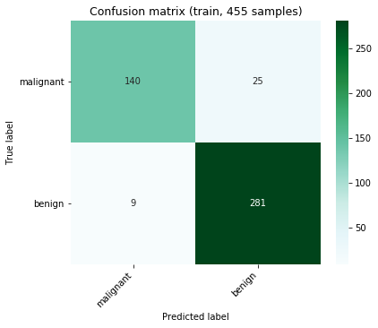

```python
print_confusion_matrix(cmat_train,
                       bc.target_names,
                       plt_title='Confusion matrix (train, 455 samples)')
```

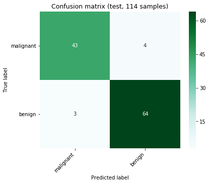

```python
print_confusion_matrix(cmat_test,
                       bc.target_names,
                       plt_title='Confusion matrix (test, 114 samples)')
```